# Řešení překryvů sekvenčních oblastí

21 února 2019

# 1 Úvod

V oblasti bioinformatiky se velice často setkáváme s potřebou identifikace různých motivů v nukleotidových sekvencích, kterým přisuzujeme specifický biologický význam. Může se jednat o oblasti genů, promotorů, nebo o oblasti, které tvoří alternativní sekundární či terciární struktury – např. [palindromy](https://en.wikipedia.org/wiki/Palindromic_sequence) (vlásenkové struktury), [triplexy](https://en.wikipedia.org/wiki/Triple-stranded_DNA) nebo [G-quadruplexy](https://en.wikipedia.org/wiki/G-quadruplex).

Algoritmy pro vyhledávání sekvenčních motivů bývají obvykle navrženy tak, že nejprve identifikují všechny sekvenční oblastí vyhovující danému motivu, bez ohledu na to, zda-li se mohou překrývat nebo ne. Následně u takových motivů, u nichž z biologického hlediska nedává smysl, aby se vzájemně překrývali (např. geny bakterií nebo oblasti tvořící alternativní strukturu), nutně navazuje filtrační krok. Ten musí vybrat nejlépe takovou vzájemně nepřekrývající se podmožinu ze všech motivů, která nejpřesněji popisuje skutečnost pozorovanou v biologických experimentech (např. reálnou skladbu genů v organismu nebo konkrétní složení sekundárních struktur).

Abyste získali základní přehled o tom, jak může takový filtrační krok vypadat, je vašim úkolem je implementovat algoritmus, který bude výše zmíněné překryvy automatizovaně řešit optimálním způsobem vzhledem k definovanému kritériu. Podrobnosti jsou uvedeny dále v textu.

# 2 Základní zadání

Implementujte algoritmus, který transformuje níže definovaný vstup na výstup s využitím principu [dynamického programování](https://en.wikipedia.org/wiki/Dynamic_programming). Inspirujte se existujícími algoritmy a prostudujte si text [Outline for Dynamic Programming](http://www.cs.cornell.edu/courses/cs482/2007sp/dynamic.pdf).

**Vstup:** Množina $X \subset \mathbb{N}$ a funkce $s: X \rightarrow \mathbb{N}$, $e: X \rightarrow \mathbb{N}$ a $q: X \rightarrow \mathbb{R}$, přičemž $X$ je množina identifikátorů vstupních sekvenčních oblastí, funkce $s$ přiřazuje oblasti počáteční souřadnici, funkce $e$ koncovou souřadnici a funkce $q$ míru kvality daného motivu (tzv. skóre). Množina oblastí na vstupu **nemá definované pořadí**.

**Výstup:** Množina $Y \subseteq X$ taková, že $\nexists\,i, j \in Y: i \neq j \wedge s(i) \leq s(j) \wedge e(i) \geq s(j)$ a současně hodnota $\sum_{i \in Y} q(i)$ je maximální možná. Jinak řečeno, sekvenční oblasti na výstupu nesmí mít mezi sebou **žádný překryv** a zároveň součet skóre výstupních sekvenčních oblastí musí být **maximální možný**. Pokud existuje více řešení se stejným maximálním skóre, může být výstupem **libovolné z nich.**

**Příklad vstupu:** Tři oblasti se skóre 10, 30 a 25. Začátek a konec oblastí je vyznačen délkou obdélníka. Oblasti, které jsou pod sebou, se překrývají.

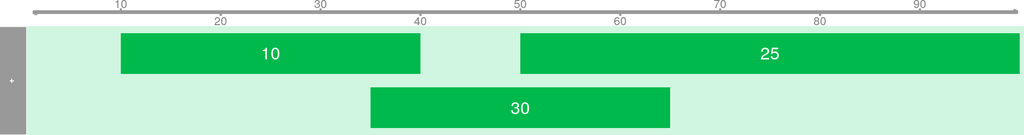

**Očekávaný výstup:** Oblasti se skóre 10 a 25. Maximální součet skóre je tedy **35**.

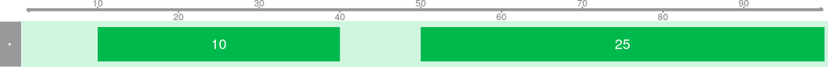

# 3 Podrobnosti k implementaci

1. Algoritmus implementujte jako **skript v jazyce Python** s názvem `resolve_overlaps.py`, který bude spustitelný na studentském serveru merlin. K řešení využívejte pouze takové knihovny jazyka Python, které jsou na serveru merlin nainstalovány. Pokud váš skript nepůjde na serveru merlin spustit, bude pravděpodobně hodnocen za **0 bodů.**
2. Na prvním řádku skriptu **správně uveďte cestu k interpretu** (shebang `#!`), aby nebylo nutné zjišťovat, pro kterou verzi interpretu jazyka Python je skript určen (na serveru merlin jich máte k dispozici hned několik).
3. Předpokládejte, že před spuštěním vašeho skriptu bude dostatečně zvýšen limit virtuální paměti (příkaz `ulimit -v`).
4. Skript bude přijímat jeden povinný vstupní parametr reprezentující jméno vstupního souboru a **výstup bude generovat na standardní výstup**.
5. Množina sekvenčních oblastí na vstupu i výstupu bude **ve formátu GFF3**, který se standardně využívá pro ukládání sekvenčních anotací. Než začnete projekt řešit, prostudujte si jeho [specifikaci](https://github.com/The-Sequence-Ontology/Specifications/blob/master/gff3.md). Pozor, skóre oblasti v GFF3 může být desetinné číslo.
6. Na vstupu **předpokládejte validní GFF3 soubor** a skriptem **generujte opět validní GFF3 soubor**.
7. Pro zachování jednoduchosti zpracování předpokládejte, že vstupní **GFF3 soubor bude pouze osmisloupcový**, tj. bez nepovinného sloupce `attributes` a nebude obsahovat žádné sekvence ve FASTA formátu.
8. Správnou funkci vašeho skriptu si můžete **ověřit na ukázkovém vstupním souboru** [pqs_chr7_hg38.gff](http://www.fit.vutbr.cz/~ihon/bif/2019/pqs_chr7_hg38.tar.gz), který obsahuje všechny potenciální G-kvadruplexy nalezené programem [pqsfinder](http://bioconductor.org/packages/pqsfinder/) na 7. chromosomu referenčního lidského genomu hg38 (celkem 8 617 709 oblastí). Maximální možná hodnota součtu skóre nepřekrývajících se oblastí na výstupu je v případě tohoto vstupu 8 528 921 pro přímé a 8 626 118 pro reverzní vlákno.
9. Mějte na paměti, že **kvalita a čitelnost vašeho kódu bude mít výrazný vliv na výsledné hodnocení.**
10. Algoritmus implementujte tak, aby pracoval **efektivně**. Příliš pomalé implementace budou bodově penalizovány. Pro ověření rychlosti implementace můžete opět využít ukázkový soubor [pqs_chr7_hg38.gff](http://www.fit.vutbr.cz/~ihon/bif/2019/pqs_chr7_hg38.tar.gz). Váš skript by měl být schopen tento soubor zpracovat v řádu jednotek (maximálně desítek) minut na běžném stroji s 8 GB RAM.

# 4 Poznámky k formátu GFF3

Formát GFF3 umožňuje uložit obecně více druhů sekvenčních oblastí/motivů v jednom souboru (viz definice sloupce `type` ve [specifikaci](https://github.com/The-Sequence-Ontology/Specifications/blob/master/gff3.md)). Konkrétní druhy motivů se pak mohou vztahovat k různým sekvencím (sloupec `seqid`) nebo vláknům DNA (sloupec `strand`). Proto předpokládejte, že sekvenční oblasti uvedené ve stupním GFF3 souboru se **mohou překrývat pouze tehdy**, mají-li identické hodnoty ve sloupcích `seqid`, `type` a `strand`.

Následuje příklad GFF3 souboru, který obsahuje dvě různé skupiny sekvenčních oblastí. První skupina byla nalezena na přímém a druhá na reverzním vlákně. Všechny oblasti se vztahují k DNA sekvenci prvního chromozomu, byli identifikovány algoritmem [pqsfinder](http://bioconductor.org/packages/pqsfinder/) a jsou typu [G_quartet](http://www.sequenceontology.org/browser/current_svn/term/SO:0000003).

```
##gff-version 3
##source-version rtracklayer 1.42.1
##date 2019-02-21
chr1    pqsfinder   G_quartet   10  39  30  +   .
chr1    pqsfinder   G_quartet   50  89  85  +   .
chr1    pqsfinder   G_quartet   30  59  90  +   .
chr1    pqsfinder   G_quartet   5   39  40  -   .
chr1    pqsfinder   G_quartet   20  49  50  -   .
chr1    pqsfinder   G_quartet   35  69  37  -   .
```

Pro lepší představu o překryvech mezi potenciálními G-kvadruplexy uvádíme i grafickou reprezentaci. Zvlášť jsou zobrazeny G-kvadruplexy na přímém (zeleně) a reverzním vlákně (červeně). Hodnota uvnitř oblastí značí skóre.

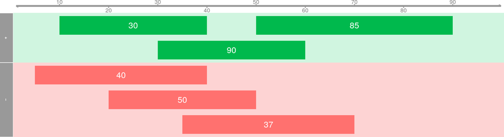

Z grafické reprezentace je poměrně snadno patrné, že pokud by byl výše uvedený GFF3 soubor zadán na vstupu programu `resolve_overlaps.py`, správný výstup by měl vypadat takto:

```
##gff-version 3
##source-version rtracklayer 1.42.1
##date 2019-02-21
chr1    pqsfinder   G_quartet   10  39  30  +   .
chr1    pqsfinder   G_quartet   50  89  85  +   .
chr1    pqsfinder   G_quartet   20  49  50  -   .
```

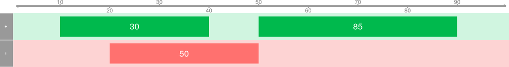

Maximální dosažitelný součet skóre nepřekrývajících se G-kvadruplexů je tedy 115 pro přímé a 50 pro reverzní vlákno prvního chromosomu.

# 5 Odevzdání

Do informační systému odevzdejte pouze skript `resolve_overlaps.py`.

# 6 Konzultace

Pro doplňující otázky k zadání využijte přednostně fórum k projektu ve WIS nebo kontaktujte přímo zadávajícího na ihon@fit.vutbr.cz. Na stejné adrese si můžete domluvit i osobní konzultaci.

# 7 Bonusové rozšíření

Všimněte si, že algoritmy pro vyhledávání sekvenčních vzorů reportují nalezené oblasti v jistém definovaném pořadí a zároveň často bývá omezená jejich maximální délka. Pokud algoritmus prochází sekvenci postupně od začátku do konce, bývají oblasti na výstupu **seřazené podle počáteční pozice**. Zkuste této vlastnosti využít ke znatelnému **snížení časové i paměťové náročnosti** vašeho algoritmu. Za efektivní a čitelnou implementaci můžete získat **až 2 bonusové body**.

Pokud se rozhodnete rozšíření implementovat, přidejte do vašeho řešení nový volitelný přepínač `-s`, jehož přítomnost při spuštění skriptu pro vás bude znamenat, že vstupní GFF soubor je seřazen podle počáteční souřadnice. Bude tedy sloužit k **zapnutí** optimalizovaného řešení. Jako testovací vstup můžete opět využít soubor [pqs_chr7_hg38.gff](http://www.fit.vutbr.cz/~ihon/bif/2019/pqs_chr7_hg38.tar.gz).

Základní myšlenku vaší optimalizační techniky prosím popište přímo do zdrojového kódu a nezapomeňte, že optimalizované řešení stále musí pracovat bezchybně, tzn. musí především splňovat všechny základní požadavky.